# covariance_pearson_correlation

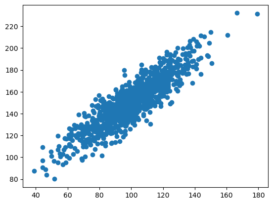

```
data1: mean=100.776 stdv=19.620
data2: mean=151.050 stdv=22.358
Covariance: 389.755
Pearsons correlation: 0.888
```

```python
# calculate the Pearson's correlation between two variables
from numpy import mean
from numpy import std
from numpy import cov
from numpy.random import randn
from numpy.random import seed
from matplotlib import pyplot as plt
import seaborn as sns

from scipy.stats import pearsonr
# seed random number generator
seed(1)

# prepare data
data1 = 20 * randn(1000) + 100
data2 = data1 + (10 * randn(1000) + 50)

# calculate covariance matrix
covariance = cov(data1, data2)

# calculate Pearson's correlation
corr, _ = pearsonr(data1, data2)

# plot
plt.scatter(data1, data2)
plt.show()

# summarize
print('data1: mean=%.3f stdv=%.3f' % (mean(data1), std(data1)))
print('data2: mean=%.3f stdv=%.3f' % (mean(data2), std(data2)))
print('Covariance: %.3f' % covariance[0][1])
print('Pearsons correlation: %.3f' % corr)
```

With regards to the above covariance, we see that the covariance is a positive number. The covariance only indicates the direction of the linear relationship between the two sets. A positive covariance means that as one variable increases, the other tends to also increase and vice versa. A negative covariance indicates as one variable increases the other variable will decrease.

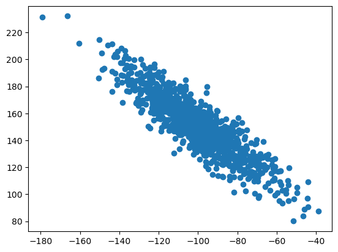

```
data1: mean=-100.776 stdv=19.620
data2: mean=151.050 stdv=22.358
Covariance: -389.755
```

```python
# seed random number generator

# prepare data
xdata1 = data1 * -1
#xdata2 = data1 + (10 * randn(1000) + 50)

# calculate covariance matrix
xcovariance = cov(xdata1, data2)


# # plot
plt.scatter(xdata1, data2)
plt.show()

# # summarize
print('data1: mean=%.3f stdv=%.3f' % (mean(xdata1), std(xdata1)))
print('data2: mean=%.3f stdv=%.3f' % (mean(data2), std(data2)))
print('Covariance: %.3f' % xcovariance[0][1])
```

In the example above, I took the negation of x (data1). Now, the covariance is a negative number, indicating that as x decreases, y increases (as seen in the scatter plot). However, the actual value of the covariance does not convey much about the strength of the relationship. To obtain a standardized measure of both the strength and direction of the linear relationship, we use the correlation coefficient. In this exercise, we utilize Pearson's correlation coefficient

```python
# calculate Pearson's correlation of positive covariance
corr, _ = pearsonr(data1, data2)


# calculate Pearson's correlation of negative covariance
xcorr, x = pearsonr(xdata1, data2)

print('Pearsons correlation of positive covariance: %.3f' % corr)
print('Pearsons correlation of positive negative: %.3f' % xcorr)
```

```
Pearsons correlation of positive covariance: 0.888
Pearsons correlation of positive negative: -0.888
```

```python
x = [2.1,2.5,4.0,3.6]
y = [8,12,14,10]

covariance = cov(x,y)
print("covariance: ", covariance[0][1])

#calculate Pearson's correlation:
corr, _ = pearsonr(x, y)
print("Pearson's correlation: ", corr)
```

```
covariance:  1.5333333333333332
Pearson's correlation:  0.6625738822030289
```